# Part3 Python的可视化技巧梳理

### Alex Fang（Tsinghua University）

### 信息科学与技术学部，Alex.holla@foxmail.com

**摘要: ** 在这一次的笔记中，我将以Part1与Part2的内容作为例子，系统性地总结几种时下比较常见的**Python可视化方法**。内容选自官网的tutorial以及众多CSDN博客，再次感谢各位Python开源工作者。这部分笔记分为3个部分，第一部分是最为常见的**matplotlib**；第二部分是比较花哨比较热门的**seaborn**；第三部分是介绍一些比较前言，且更加花里胡哨的例子，比如python与**echarts**的可视化工具，又比如可视化RNN的训练过程（有专门关于黑箱inspection的研究，算是一个open challenge,我挑一个最简单的例子来展示动态可视化技巧）。

**关键字：**Python可视化技巧；matplotlib；seaborn；encharts

## 第一章 Matplotlib

在数据科学中，数据可视化是研究的其中一部份工作，它是为了将处理后的数据呈现给需要的人，因为有时候有规律的结果需要以图表的形式呈 现，即使如此，人们从呈现出来的图表获取的信息量还远远不够，这就要求画图者需要使用多样化的图表来呈现结果。在Python中，最常见的可视化工具就是Matplotlib，这是一个绘制2D和3D科学图像的库，它包含了以下的优点：

1.容易学习和掌握

2.兼容LaTeX格式的标题和文档

3.可以控制图像中的每个元素，包括图像大小和扫描精度

4.对于很多格式都可以高质量的输出图像，包括PNG，PDF，SVG，EPS和PGF

5.可以生成图形用户界面（GUI），做到交互式的获取图像以及无脑生成图像文件（通常用于批量作业）

6.Matplotlib最重要的一个特点，也是它作出的图像非常适合作为科学出版物的原因，是因为图像可以完全被程序所控制。这一点对于图像重现非常重要，同时为更新数据后重新作图以及改变图像形状提供了方便。更多关于Matplotlib网页请见http://matplotlib.org/

## $\S1.1$画一次所有类型的图（低配版）

1.先画一次低配版的各种类型的图，如果有需要，可以按照自己的风格进行修改、并保存为自己常用的模板，提高代码复用率

2.此外，后文中关于改变颜色、图片风格等内容都将以散点图或折线图为例，在饼图、柱形图等方面就不再穷举，希望各位可以自己动手尝试，并存为泛化能力较强的模板。总而言之，可视化非常非常重要，但是写代码这个部分花的时间越少越好

3.大部分参数都会注释，极少部分参数会单独强调。可视化部分请尽量多阅读代码

```python
#生成数据
import numpy

x=numpy.linspace(1,100,100)
noise=numpy.random.rand(100)*10
y=x+noise
```

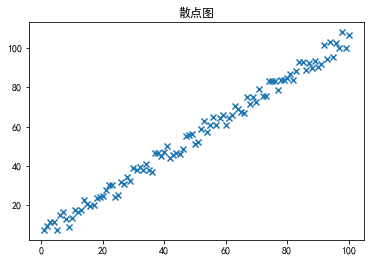

```python
import matplotlib.pyplot as plt

plt.rcParams['font.sans-serif']=['SimHei'] #用来正常显示中文标签
plt.rcParams['axes.unicode_minus']=False #用来正常显示负号，在最新版的matplotlib中已经不需要加入这句了
plt.title('散点图')
#marker是点的形状
plt.scatter(x,y,marker='x')
plt.show()
```

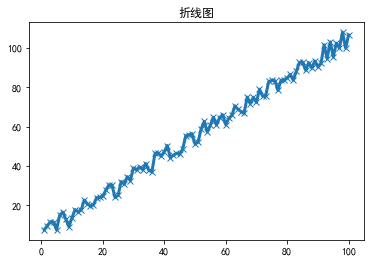

```python
plt.rcParams['font.sans-serif']=['SimHei'] #用来正常显示中文标签
plt.rcParams['axes.unicode_minus']=False #用来正常显示负号，在最新版的matplotlib中已经不需要加入这句了
plt.title('折线图')
#线的粗细linewidth,marker同理
plt.plot(x,y,marker='x',linewidth=3)
plt.show()
```

```
Text(0.5,1,'饼图')
```

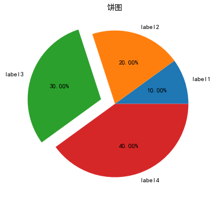

```python
plt.figure(figsize=(5,5),dpi=80)
plt.axis('equal')
explode1=(0,0,0.2,0)#0代表聚合在一起，想让哪块饼突出一点，就将之设为非0，越大，则越突出
plt.pie([0.1,0.2,0.3,0.4],labels=['label1','label2','label3','label4'],explode=explode1,autopct='%.2f%%')
plt.title('饼图')
```

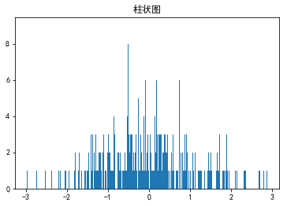

```python
plt.title('柱状图')
s=numpy.random.normal(0,1,1000)
plt.hist(s,bins=1000)
plt.show()
```

## $\S1.2$关于细节

#### 颜色

官网有关于自己**根据RGB比例调颜色**的教程，感兴趣的同学可以看一下：https://matplotlib.org/tutorials/colors/colorbar_only.html#sphx-glr-tutorials-colors-colorbar-only-py

#### 标注

标注大致包括x,y轴的标注；图例的标注；图片标题的标注

而图例的标注中又包括特殊点的标注（比如最大收益、最大回撤点），这个可以做的比较酷炫比较复杂，我给出两个基础实例

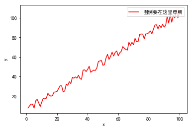

```python
#x,y轴的标注
plt.xlabel('x')
plt.ylabel('y')
plt.plot(x,y,color='r',label='图例要在这里申明')
#图例的位置
#当然也可以upper left 或lower left...
plt.legend(loc='upper right')
plt.show()
```

两种方式标注x=50这一特殊点，所谓特殊点，你还是需要事先求出这个点的坐标的。

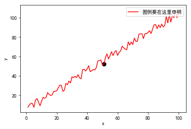

```python
#方法1，单独画出这个点，且为之设置很大的linewidth和很显眼的颜色
special_x=x[50]
special_y=y[50]

plt.xlabel('x')
plt.ylabel('y')
plt.plot(x,y,color='r',label='图例要在这里申明')
plt.scatter(special_x,special_y,marker='x',color='k',linewidth=5)
#图例的位置
#当然也可以upper left 或lower left...
plt.legend(loc='upper right')
plt.show()
```

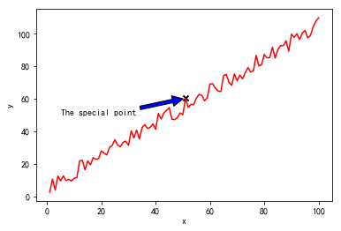

```python
#方法2,使用类似注释框的形式，指向这一点,结合方法1，可以使之较为完整化
special_x=x[50]
special_y=y[50]

plt.xlabel('x')
plt.ylabel('y')
plt.plot(x,y,color='r')
plt.scatter(special_x,special_y,marker='x',color='k',linewidth=2)

#指向这一点
#第一组XY是箭头的坐标，第二组XY是箭尾的坐标（需要手动调试，或者用做差计算）
plt.annotate(u"The special point", xy = (special_x, special_y), xytext = (5, 50),arrowprops=dict(facecolor='blue', shrink=0.05))

plt.show()
```

#### 多条曲线

画出多条曲线，并为之标注

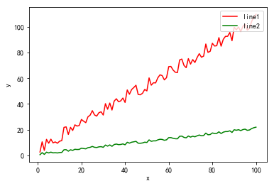

```python
plt.xlabel('x')
plt.ylabel('y')
plt.plot(x,y,color='r',label='line1')
plt.plot(x,y/5,color='g',label='line2')
plt.legend(loc='upper right')
```

#### 双坐标轴

将两个跨度相差极大的坐标轴放在一张图中，可以起到方便比较的作用

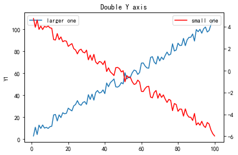

```python
fig = plt.figure()
ax1 = fig.add_subplot(111)
ax1.plot(x, y,label='larger one')
ax1.set_ylabel('Y1')
ax1.set_title("Double Y axis")

ax2 = ax1.twinx()  # this is the important function
ax2.plot(x, (50-y)/10,color='r',label='small one')
ax1.legend(loc='upper left')
ax2.legend(loc='upper right')
```

#### 多张子图

将多张子图放在一张图内，可以起到简洁、方便比较的作用。大多数计算机类会议论文都是6-10页的篇幅，但是包含大量实验信息，一方面是依赖于子图。另一方面，如果需表达信息过多，其实也就不放图片了，而是一张表汇总数10张图的信息。

比较常见的子图创建是用fig = plt.figure()；ax1 = fig.add_subplot(2, 2, 1)来创建一个2行2列的位置，然后对第一张图进行绘制。这样做在改变画布大小时不太方便，且并不直观。我偏向以下这种方法：

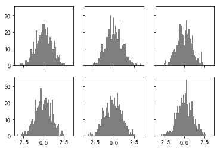

```python
fig, axes = plt.subplots(2, 3, sharex=True, sharey=True)
for i in range(2):
    for j in range(3):
        axes[i, j].hist(numpy.random.randn(500), bins=50, color='k', alpha=0.5)
```

## $\S1.3$图像美化

可视化还是比较依赖手动调整的，毕竟teaser或者研报的颜值还是非常重要的。完全值得我们编程后还手动调整，追求极致。

#### 改变图像大小，使之合适

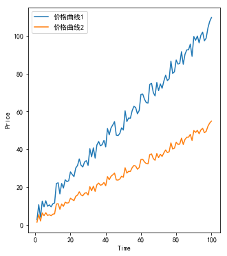

```python
fig,ax = plt.subplots(figsize = (5,6))
ax.set_xlabel('Time')
ax.set_ylabel('Price')
ax.plot(x,y,label="价格曲线1")
ax.plot(x,y/2,label="价格曲线2")
ax.legend(loc='upper left')
```

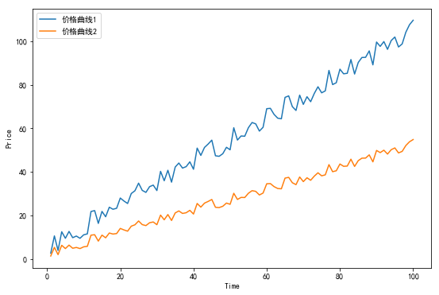

```python
fig,ax = plt.subplots(figsize = (9,6))
ax.set_xlabel('Time')
ax.set_ylabel('Price')
ax.plot(x,y,label="价格曲线1")
ax.plot(x,y/2,label="价格曲线2")
ax.legend(loc='upper left')
```

#### 改变字体

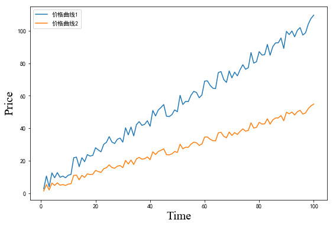

```python
font1 = {'family' : 'Times New Roman',
'weight' : 'normal',
'size'   : 20,
}

fig,ax = plt.subplots(figsize = (9,6))
ax.set_xlabel('Time',font1)
ax.set_ylabel('Price',font1)
ax.plot(x,y,label="价格曲线1")
ax.plot(x,y/2,label="价格曲线2")
ax.legend(loc='upper left')
```

#### 改变线条颜色与粗细

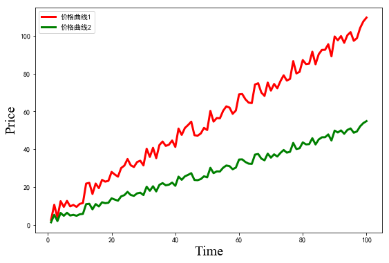

```python
font1 = {'family' : 'Times New Roman',
'weight' : 'normal',
'size'   : 20,
}

fig,ax = plt.subplots(figsize = (9,6))
ax.set_xlabel('Time',font1)
ax.set_ylabel('Price',font1)
ax.plot(x,y,label="价格曲线1",linewidth=3,color='r')
ax.plot(x,y/2,label="价格曲线2",linewidth=3,color='g')
ax.legend(loc='upper left')
```

#### 网格化

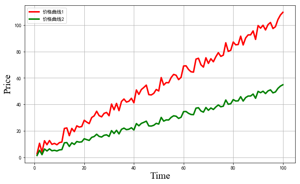

```python
font1 = {'family' : 'Times New Roman',
'weight' : 'normal',
'size'   : 20,
}

fig,ax = plt.subplots(figsize = (10,6))
ax.set_xlabel('Time',font1)
ax.set_ylabel('Price',font1)
ax.plot(x,y,label="价格曲线1",linewidth=3,color='r')
ax.plot(x,y/2,label="价格曲线2",linewidth=3,color='g')
ax.legend(loc='upper left')
plt.grid()
```

#### 样式

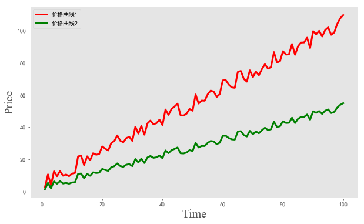

```python
#据说这个style是最好看的，无审美能力的我表示随便吧，我听老板的意思
plt.style.use("ggplot")
font1 = {'family' : 'Times New Roman',
'weight' : 'normal',
'size'   : 20,
}

fig,ax = plt.subplots(figsize = (10,6))
ax.set_xlabel('Time',font1)
ax.set_ylabel('Price',font1)
ax.plot(x,y,label="价格曲线1",linewidth=3,color='r')
ax.plot(x,y/2,label="价格曲线2",linewidth=3,color='g')
ax.legend(loc='upper left')
plt.grid()
```

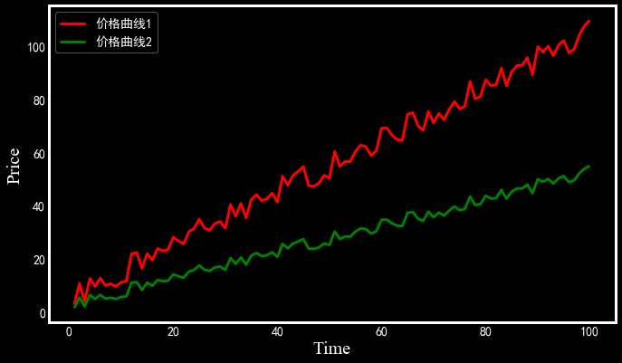

```python
plt.style.use("dark_background")

font1 = {'family' : 'Times New Roman',
'weight' : 'normal',
'size'   : 20,
}

fig,ax = plt.subplots(figsize = (10,6))
ax.set_xlabel('Time',font1)
ax.set_ylabel('Price',font1)
ax.plot(x,y,label="价格曲线1",linewidth=3,color='r')
ax.plot(x,y/2,label="价格曲线2",linewidth=3,color='g')
ax.legend(loc='upper left')
plt.grid()
```

关于matplotlib的知识点就暂时整理到这里，用于完成量化投资实践课程的作业可能已经足够。整理着整理着发现想说的还有挺多，然而寒假大半已用在笔记整理上，我抓紧剩下时间说一说其他可视化工具吧，未尽事宜还请在CSDN、简书、GitHub、help()查找。

## 第二章 Seaborn

Seaborn是一种专为统计结果可视化而设计的库，他在matplotlib的基础上设计，因此支持并与matplotlib极为相似。与pandas的dataframe数据格式有非常好的耦合性，有许多相关的方法。官网tutorial: http://seaborn.pydata.org/introduction.html

首先要介绍的是seaborn对pandas的良好支持，我们使用一组公开数据集。以一个简单的例子让你体会seaborn对pandas有多么支持。所以，以后的路径可以是list-matplotlib-seaborn; 亦可以是excel-pandas-dataframe-seaborn.

```
   total_bill   tip     sex smoker  day    time  size
0       16.99  1.01  Female     No  Sun  Dinner     2
1       10.34  1.66    Male     No  Sun  Dinner     3
2       21.01  3.50    Male     No  Sun  Dinner     3
3       23.68  3.31    Male     No  Sun  Dinner     2
4       24.59  3.61  Female     No  Sun  Dinner     4
```

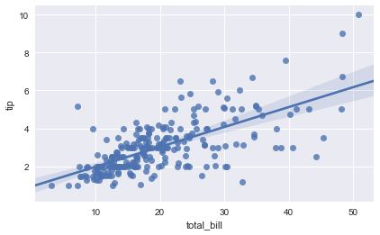

```python
tips = sns.load_dataset("tips")

print(tips.head(5))

#直接将这个dataframe的列名打出即可，而dataframe的名称叫做tips
sns.regplot(x="total_bill", y="tip", data=tips)
plt.show()
```

## $\S2.1$风格增强

Seaborn是在matplotlib的基础上设计的，所以Seaborn与matplotlib有很好的兼容性。初识Seaborn,我没有意识到其在seaborn在统计数据可视化方面的强大实力，仅仅惊叹于其姣好的面容。所以，我很肤浅地用seaborn对我写好的matplotlib代码做一个增强，相当于p一下图。Seaborn一共支持5中风格： 1.darkgrid（灰色网格） 2.whitegrid（白色网格） 3.dark（黑色） 4.white（白色） 5.ticks（十字叉）

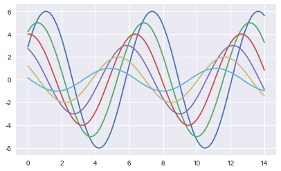

```python
#单独使用matplotlib画图：
import numpy as np
import matplotlib.pyplot as plt
%matplotlib inline
def sinplot(flip=1):
    x = np.linspace(0, 14, 100)
    for i in range(1, 7):
        plt.plot(x, np.sin(x + i * .5) * (7 - i) * flip)

sns.set_style("darkgrid")
sinplot()
```

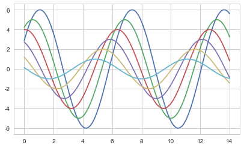

```python
sns.set_style("whitegrid")
sinplot()
```

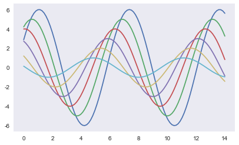

```python
sns.set_style("dark")
sinplot()
```

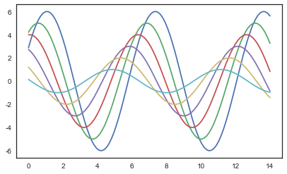

```python
sns.set_style("white")
sinplot()
```

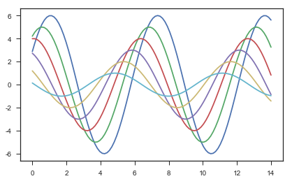

```python
sns.set_style("ticks")
sinplot()
```

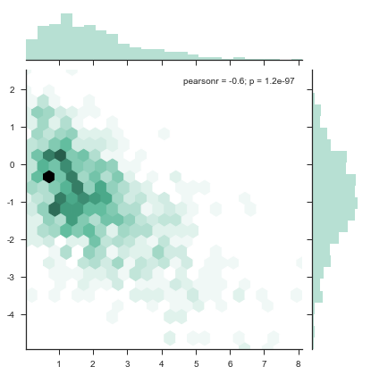

```python
import numpy as np
import seaborn as sns
sns.set(style="ticks")

rs = np.random.RandomState(11)
x = rs.gamma(2, size=1000)
y = -.5 * x + np.random.normal(size=1000)

sns.jointplot(x, y, kind="hex", color="#4CB391")
```

似乎，就目前看来并没有比matplotlib漂亮太多...但是没关系，你可以参考官网的“gallery”,在里面挑选合眼缘的模板。 http://seaborn.pydata.org/examples/index.html#

## $\S2.1$一套例子（展示seaborn在统计数据可视化方面的优势）

其实说seaborn简单，也只是指用一行代码能画复杂的图。但是函数内需要传入的参数还是比matplotlib多很多的。建议每次用的时候直接help()查询参数吧

```python
import seaborn
help(seaborn.distplot)
```

```
Help on function distplot in module seaborn.distributions:

distplot(a, bins=None, hist=True, kde=True, rug=False, fit=None, hist_kws=None, kde_kws=None, rug_kws=None, fit_kws=None, color=None, vertical=False, norm_hist=False, axlabel=None, label=None, ax=None)
    Flexibly plot a univariate distribution of observations.

    This function combines the matplotlib ``hist`` function (with automatic
    calculation of a good default bin size) with the seaborn :func:`kdeplot`
    and :func:`rugplot` functions. It can also fit ``scipy.stats``
    distributions and plot the estimated PDF over the data.

    Parameters
    ----------

    a : Series, 1d-array, or list.
        Observed data. If this is a Series object with a ``name`` attribute,
        the name will be used to label the data axis.
    bins : argument for matplotlib hist(), or None, optional
        Specification of hist bins, or None to use Freedman-Diaconis rule.
    hist : bool, optional
        Whether to plot a (normed) histogram.
    kde : bool, optional
        Whether to plot a gaussian kernel density estimate.
    rug : bool, optional
        Whether to draw a rugplot on the support axis.
    fit : random variable object, optional
        An object with `fit` method, returning a tuple that can be passed to a
        `pdf` method a positional arguments following an grid of values to
        evaluate the pdf on.
    {hist, kde, rug, fit}_kws : dictionaries, optional
        Keyword arguments for underlying plotting functions.
    color : matplotlib color, optional
        Color to plot everything but the fitted curve in.
    vertical : bool, optional
        If True, oberved values are on y-axis.
    norm_hist : bool, optional
        If True, the histogram height shows a density rather than a count.
        This is implied if a KDE or fitted density is plotted.
    axlabel : string, False, or None, optional
        Name for the support axis label. If None, will try to get it
        from a.namel if False, do not set a label.
```

[output cut: 65 more lines]

```
    .. plot::
        :context: close-figs

        >>> sns.set_color_codes()
        >>> ax = sns.distplot(x, color="y")

    Pass specific parameters to the underlying plot functions:

    .. plot::
        :context: close-figs

        >>> ax = sns.distplot(x, rug=True, rug_kws={"color": "g"},
        ...                   kde_kws={"color": "k", "lw": 3, "label": "KDE"},
        ...                   hist_kws={"histtype": "step", "linewidth": 3,
        ...                             "alpha": 1, "color": "g"})
```

### 单变量的研究--推荐使用直方图

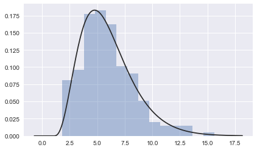

```python
import numpy as np
import seaborn as sns
from scipy import stats, integrate
%matplotlib inline
sns.set(color_codes=True)
np.random.seed(sum(map(ord, "distributions")))#每次产生的随机数相同
x = np.random.gamma(6, size=200)
sns.distplot(x, kde=False, fit=stats.gamma)

#其中kde=false表示Whether to plot a gaussian kernel density estimate.
#fit=stats.gamma表示用gamma分布进行拟合
```

### 散点图-描述二元变量的关系

```
          x         y
0  0.109574  0.902183
1  1.087794  0.776813
2 -0.287058 -0.233632
3  2.202301  3.059491
4 -0.080046 -0.368889
```

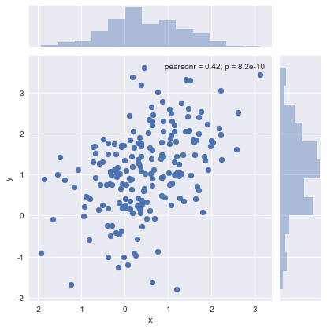

```python
import numpy as np
import pandas as pd
import seaborn as sns
import matplotlib.pyplot as plt
from scipy import stats, integrate
%matplotlib inline
sns.set(color_codes=True)
mean, cov = [0.5, 1], [(1, .5),(.5, 1)]#设置均值(一组参数)和协方差（两组参数）
data = np.random.multivariate_normal(mean, cov, 200)
df = pd.DataFrame(data, columns=["x", "y"])
print(df.head())
sns.jointplot(x="x", y="y", data=df)
plt.show()
```

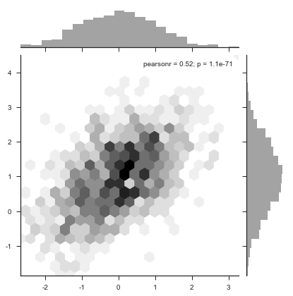

```python
#之前是200个数据点，但数据量很大时，比如说1000个点，可以用hex来画散点图
import numpy as np
import pandas as pd
import seaborn as sns
import matplotlib.pyplot as plt
from scipy import stats, integrate
%matplotlib inline
sns.set(color_codes=True)
mean, cov = [0, 1], [(1, .5), (.5, 1)]
x, y = np.random.multivariate_normal(mean, cov, 1000).T
with sns.axes_style("ticks"):
    sns.jointplot(x=x, y=y, kind="hex", color="k")
plt.show()
```